# STSCI 5030 - Fall 2018 - HW2 Q1

Harry Lu, dl947

Due Friday, September 28, 2018

This question follows on from Q2 of HW 1. As in that case, the file `brainweight.txt` contains measurements of **brain weight** (B, in kilograms), **body weight** (W, in kilograms), and **gestation period** (G, in days) of a sample of 96 mammal species. The following commands can be used to read the data into R (although you will need point the **setwd** command to the directory on your computer that contains the data file.).

Here we will continue to look at multiple linear regression and how association between variables impacts inference. Question 2 will explore these results mathematically.

# Read data

```r
brain_data=read.table("Homework 2/BrainWeight.txt",header=TRUE)
#colnames(brain_data)=c("B","W","G")
brain_data$ln_B=log(brain_data$Brain,base=exp(1))
brain_data$ln_W=log(brain_data$Body,base=exp(1))
brain_data$ln_G=log(brain_data$Gestation,base=exp(1))
```

# a

> Fit a regression model to predict log(B) from log(W). Create the hat matrix for this regression.

```r
l_BW=lm(brain_data$ln_B~brain_data$ln_W)
l_BW
```

```
##
## Call:
## lm(formula = brain_data$ln_B ~ brain_data$ln_W)
##
## Coefficients:
##     (Intercept)  brain_data$ln_W
##          2.3324           0.7192
```

$$\ln{\text{B}}=2.3324+0.7192\cdot\ln{\text{W}}$$

```r
BW_X=matrix(1,nrow=96,ncol=2)
BW_X[,2]=brain_data$ln_W
BW_H=BW_X%*%solve(t(BW_X)%*%BW_X)%*%t(BW_X)
```

$X$ (`BW_X`) is the covariant matrix, which is
$$\left(\begin{array}{c}
1 & \ln{\text{W}}_1\\
\vdots & \vdots\\
1 & \ln{\text{W}_{96}}
\end{array}\right)$$

$H$ (`BW_H`) is the hat matrix, which is
$$H=X(X^TX)^{-1}X^T$$

# b

> Find the observation with the largest value of W, replace it’s value of log(B) with each of the quartiles of log(B) in turn.

> For each quartile, re-fit the regression line. Plot the estimated coefficient of log(W) for each of these four models versus the corresponding quartile of log(B).

> Similarly, plot the fitted value for the observation you manipulated versus the quartile of log(B). Show that the slope of this line is equal to the leverage (the diagonal element of the Hat matrix) for that point.

```r
quantile(brain_data$ln_B)
```

```
##         0%        25%        50%        75%       100%
## -0.7985077  2.5333105  4.3039738  5.5606816  8.4073783
```

```r
which(brain_data$ln_B==max(brain_data$ln_B))
```

```
## [1] 3
```

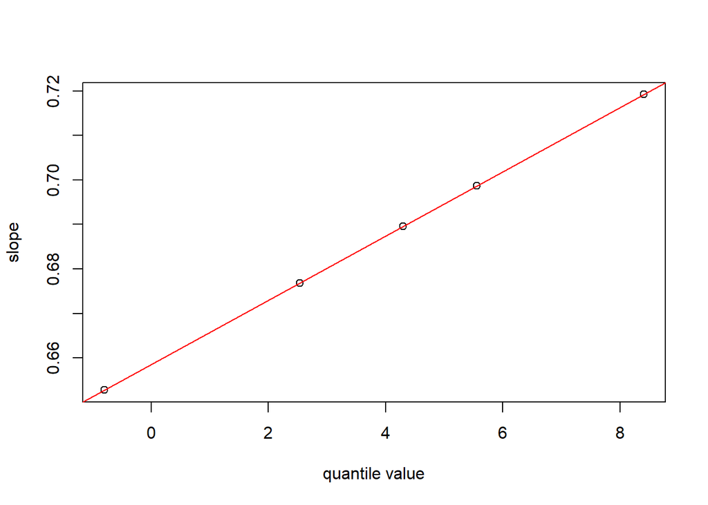

```r
#quantile = 0%
ln_B_0=brain_data$ln_B
ln_B_0[3]=quantile(brain_data$ln_B)[[1]]
l_BW_0=lm(ln_B_0~brain_data$ln_W)
fv_0=fitted.values(l_BW_0)
#quantile = 25%
ln_B_25=brain_data$ln_B
ln_B_25[3]=quantile(brain_data$ln_B)[[2]]
l_BW_25=lm(ln_B_25~brain_data$ln_W)
fv_25=fitted.values(l_BW_25)
#quantile = 50%
ln_B_50=brain_data$ln_B
ln_B_50[3]=quantile(brain_data$ln_B)[[3]]
l_BW_50=lm(ln_B_50~brain_data$ln_W)
fv_50=fitted.values(l_BW_50)
#quantile = 75%
ln_B_75=brain_data$ln_B
ln_B_75[3]=quantile(brain_data$ln_B)[[4]]
l_BW_75=lm(ln_B_75~brain_data$ln_W)
fv_75=fitted.values(l_BW_75)
#quantile = 100%
ln_B_100=brain_data$ln_B
ln_B_100[3]=quantile(brain_data$ln_B)[[5]]
l_BW_100=lm(ln_B_100~brain_data$ln_W)
fv_100=fitted.values(l_BW_100)
#x - slope, y - quantile value
BW_y=c(l_BW_0$coefficients[[2]],l_BW_25$coefficients[[2]],l_BW_50$coefficients[[2]],l_BW_75$coefficients[[2]],l_BW_100$coefficients[[2]])
BW_x=c(ln_B_0[3],ln_B_25[3],ln_B_50[3],ln_B_75[3],ln_B_100[3])
plot(x=BW_x,y=BW_y,xlab="quantile value",ylab="slope")
abline(lm(BW_y~BW_x),col="red")
```

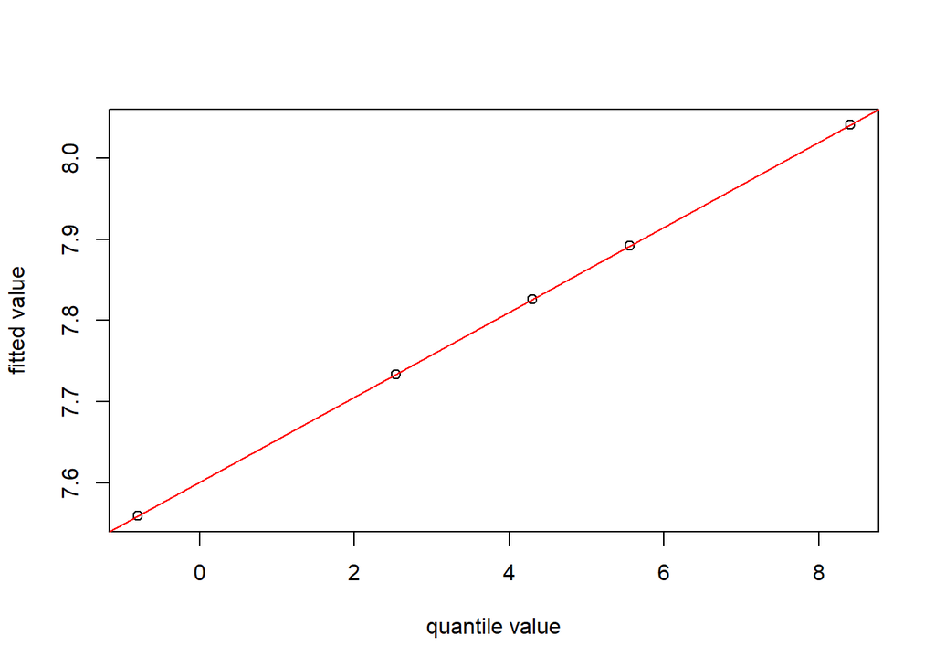

```r
fv_y=c(fv_0[3],fv_25[3],fv_50[3],fv_75[3],fv_100[3])
plot(x=BW_x,y=fv_y,xlab="quantile value",ylab="fitted value")
abline(lm(fv_y~BW_x),col="red")
```

```r
lm(fv_y~BW_x)[[1]][[2]]#slope
```

```
## [1] 0.05230153
```

```r
BW_H[3,3]#leverage
```

```
## [1] 0.05230153
```

# c

> Now we will consider fitting log(B) to both log(G) and log(W). Do this using the **lm** function two ways: 1. with log(W) listed before log(G) and 2. with log(G) before log(W).

> Use the `anova` command to obtain sequential anova tables for both models; do thse give different sum of squares?

```r
l_B_WG=lm(brain_data$ln_B~brain_data$ln_W+brain_data$ln_G)
anova(l_B_WG)
```

```
## Analysis of Variance Table
##
## Response: brain_data$ln_B
##                 Df Sum Sq Mean Sq  F value    Pr(>F)
## brain_data$ln_W  1 416.40  416.40 1732.785 < 2.2e-16 ***
## brain_data$ln_G  1   9.06    9.06   37.713 2.002e-08 ***
## Residuals       93  22.35    0.24
## ---
## Signif. codes:  0 '***' 0.001 '**' 0.01 '*' 0.05 '.' 0.1 ' ' 1
```

```r
l_B_GW=lm(brain_data$ln_B~brain_data$ln_G+brain_data$ln_W)
anova(l_B_GW)
```

```
## Analysis of Variance Table
##
## Response: brain_data$ln_B
##                 Df Sum Sq Mean Sq F value    Pr(>F)
## brain_data$ln_G  1 355.74  355.74 1480.37 < 2.2e-16 ***
## brain_data$ln_W  1  69.72   69.72  290.13 < 2.2e-16 ***
## Residuals       93  22.35    0.24
## ---
## Signif. codes:  0 '***' 0.001 '**' 0.01 '*' 0.05 '.' 0.1 ' ' 1
```

The sum of squares of two models are different.

# d

> Show that the `Anova` command in the `car` package gives the same non-sequential sums of squares for both models.

```r
library(car)
Anova(l_B_WG)
```

```
## Anova Table (Type II tests)
##
## Response: brain_data$ln_B
##                 Sum Sq Df F value    Pr(>F)
## brain_data$ln_W 69.719  1 290.126 < 2.2e-16 ***
## brain_data$ln_G  9.063  1  37.713 2.002e-08 ***
## Residuals       22.349 93
## ---
## Signif. codes:  0 '***' 0.001 '**' 0.01 '*' 0.05 '.' 0.1 ' ' 1
```

```r
Anova(l_B_WG)[1]
```

```
##                 Sum Sq
## brain_data$ln_W 69.719
## brain_data$ln_G  9.063
## Residuals       22.349
```

```r
Anova(l_B_GW)
```

```
## Anova Table (Type II tests)
##
## Response: brain_data$ln_B
##                 Sum Sq Df F value    Pr(>F)
## brain_data$ln_G  9.063  1  37.713 2.002e-08 ***
## brain_data$ln_W 69.719  1 290.126 < 2.2e-16 ***
## Residuals       22.349 93
## ---
## Signif. codes:  0 '***' 0.001 '**' 0.01 '*' 0.05 '.' 0.1 ' ' 1
```

```r
Anova(l_B_GW)[1]
```

```
##                 Sum Sq
## brain_data$ln_G  9.063
## brain_data$ln_W 69.719
## Residuals       22.349
```

# e

> Fit a model to predict log(G) from log(W) and extract the residuals from this model into an object called GW. Now examine regressing log(B) on log(W) and GW. Show that this model has the same fitted values as those in c (You can look at the maximum of the absolute differences between the fitted value vectors) and show that in this case the order in which you specify log(W) and GW makes no difference to t_he sequential ANOVA table.

```r
l_G_W=lm(brain_data$ln_G~brain_data$ln_W)
GW=l_G_W$residuals
l_B_WGW=lm(brain_data$ln_B~brain_data$ln_W+GW)
res_B_WGW=l_B_WGW$residuals
res_B_WG=l_B_WG$residuals
res_B_GW=l_B_GW$residuals
round(res_B_WGW,5)==round(res_B_GW,5)
```

```
##    1    2    3    4    5    6    7    8    9   10   11   12   13   14   15
## TRUE TRUE TRUE TRUE TRUE TRUE TRUE TRUE TRUE TRUE TRUE TRUE TRUE TRUE TRUE
##   16   17   18   19   20   21   22   23   24   25   26   27   28   29   30
## TRUE TRUE TRUE TRUE TRUE TRUE TRUE TRUE TRUE TRUE TRUE TRUE TRUE TRUE TRUE
##   31   32   33   34   35   36   37   38   39   40   41   42   43   44   45
## TRUE TRUE TRUE TRUE TRUE TRUE TRUE TRUE TRUE TRUE TRUE TRUE TRUE TRUE TRUE
##   46   47   48   49   50   51   52   53   54   55   56   57   58   59   60
## TRUE TRUE TRUE TRUE TRUE TRUE TRUE TRUE TRUE TRUE TRUE TRUE TRUE TRUE TRUE
##   61   62   63   64   65   66   67   68   69   70   71   72   73   74   75
## TRUE TRUE TRUE TRUE TRUE TRUE TRUE TRUE TRUE TRUE TRUE TRUE TRUE TRUE TRUE
##   76   77   78   79   80   81   82   83   84   85   86   87   88   89   90
## TRUE TRUE TRUE TRUE TRUE TRUE TRUE TRUE TRUE TRUE TRUE TRUE TRUE TRUE TRUE
##   91   92   93   94   95   96
## TRUE TRUE TRUE TRUE TRUE TRUE
```

```r
round(res_B_WGW,5)==round(res_B_WG,5)
```

```
##    1    2    3    4    5    6    7    8    9   10   11   12   13   14   15
## TRUE TRUE TRUE TRUE TRUE TRUE TRUE TRUE TRUE TRUE TRUE TRUE TRUE TRUE TRUE
##   16   17   18   19   20   21   22   23   24   25   26   27   28   29   30
## TRUE TRUE TRUE TRUE TRUE TRUE TRUE TRUE TRUE TRUE TRUE TRUE TRUE TRUE TRUE
##   31   32   33   34   35   36   37   38   39   40   41   42   43   44   45
## TRUE TRUE TRUE TRUE TRUE TRUE TRUE TRUE TRUE TRUE TRUE TRUE TRUE TRUE TRUE
##   46   47   48   49   50   51   52   53   54   55   56   57   58   59   60
## TRUE TRUE TRUE TRUE TRUE TRUE TRUE TRUE TRUE TRUE TRUE TRUE TRUE TRUE TRUE
##   61   62   63   64   65   66   67   68   69   70   71   72   73   74   75
## TRUE TRUE TRUE TRUE TRUE TRUE TRUE TRUE TRUE TRUE TRUE TRUE TRUE TRUE TRUE
##   76   77   78   79   80   81   82   83   84   85   86   87   88   89   90
## TRUE TRUE TRUE TRUE TRUE TRUE TRUE TRUE TRUE TRUE TRUE TRUE TRUE TRUE TRUE
##   91   92   93   94   95   96
## TRUE TRUE TRUE TRUE TRUE TRUE
```

# f

> We can examine this by the observation that if

> $$\log(G) = \gamma_0 + \gamma_1 \log(W) + GW$$

> then we can re-write the model from part c as

> $$\begin{aligned}
> \beta_0 + \beta_1 \log(W) + \beta_2 \log(G)
> &=
> \beta_0 + \beta_1 \log(W) + \beta_2 \left( \gamma_0 + \gamma_1 \log(W) + GW \right) \\
> &=
> \beta_0 + \beta_2 \gamma_0 + (\beta_1+\gamma_1\beta_2)\log(W) + \beta_2 GW
> \end{aligned}$$

> Show that the coefficients in your models satisfy this relationship

```r
gamma0=l_G_W$coefficients[[1]]
gamma1=l_G_W$coefficients[[2]]
beta0=l_B_WG$coefficients[[1]]
beta1=l_B_WG$coefficients[[2]]
beta2=l_B_WG$coefficients[[3]]
```

```r
LHS=beta0+beta1*brain_data$ln_W+beta2*brain_data$ln_G
RHS=(beta0+beta2*gamma0)+(beta1+beta2*gamma1)*brain_data$ln_W+beta2*GW
round(LHS,5)==round(RHS,5)
```

```
##    1    2    3    4    5    6    7    8    9   10   11   12   13   14   15
## TRUE TRUE TRUE TRUE TRUE TRUE TRUE TRUE TRUE TRUE TRUE TRUE TRUE TRUE TRUE
##   16   17   18   19   20   21   22   23   24   25   26   27   28   29   30
## TRUE TRUE TRUE TRUE TRUE TRUE TRUE TRUE TRUE TRUE TRUE TRUE TRUE TRUE TRUE
##   31   32   33   34   35   36   37   38   39   40   41   42   43   44   45
## TRUE TRUE TRUE TRUE TRUE TRUE TRUE TRUE TRUE TRUE TRUE TRUE TRUE TRUE TRUE
##   46   47   48   49   50   51   52   53   54   55   56   57   58   59   60
## TRUE TRUE TRUE TRUE TRUE TRUE TRUE TRUE TRUE TRUE TRUE TRUE TRUE TRUE TRUE
##   61   62   63   64   65   66   67   68   69   70   71   72   73   74   75
## TRUE TRUE TRUE TRUE TRUE TRUE TRUE TRUE TRUE TRUE TRUE TRUE TRUE TRUE TRUE
##   76   77   78   79   80   81   82   83   84   85   86   87   88   89   90
## TRUE TRUE TRUE TRUE TRUE TRUE TRUE TRUE TRUE TRUE TRUE TRUE TRUE TRUE TRUE
##   91   92   93   94   95   96
## TRUE TRUE TRUE TRUE TRUE TRUE
```